# Analyzing Twitter data of WeRateDogs

The best way to ensure you drive the right insights out of the data is to proceed with caution and a bit of uncertainy, realizing that even after a long stretch of assessment it's still easy to miss an imoportant piece here and there, starting with... columns!

If you decide to use a Jupyter Notenook and pandas for your analysis, be sure to display max columns and rows, so you don't miss any when going for a .sample() or. info(), like this:

```
pd.set_option('display.max_rows', 500)
pd.set_option('display.max_columns', 500)
pd.set_option('display.width', 1000)
```

There are multiple visualization libraries one can use, I decided to stick with the basics, matplotlib as well as seaborn.

I downloaded WeRateDogs tweet detail via API, merged it with a couple existing datasets. Assessed and cleaned it, then realized it would be interesting to see how many tweets were produced in every year based on the data I pulled, and so I built a quick pie chart. As it seems, 2016 was most fruitful as far as posted Floofers are concerned!

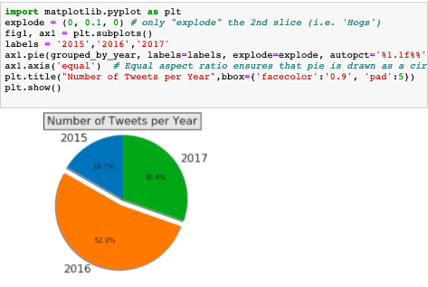

I then checked to see which Puppers got most love aka most number of favorites and retweets. Turns out, folks don't necessarily retweet Doggos that they favorite! For instance, Jamesy is added to favories way more often than Duddles, but Duddles beat Jamesy as far as retweet count goes.

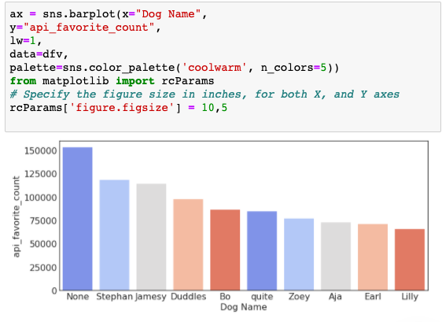

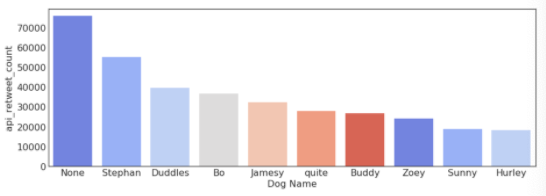

(Really love the collwarm pallette -- you can use all sorts of colors with seaborn. Also, check out the size adjustments via rcParams -- really useful when building long barplots.)

Another good idea when approaching data visualizations is to play around with visuals and see if you get some inspiration. Here is a blog describing Top 50 matplotlib plots. I played around with their density plot, which made me think of coming up with a Tweet Count by Year chart, so there's definitely more to explore!

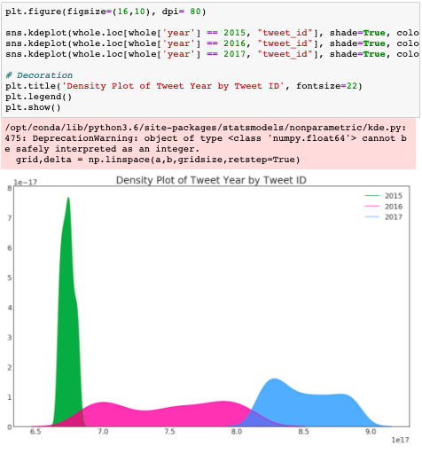